# ML One Network: Norming Variable Power Analysis

The Doom Lab

2026-07-02

## Why this analysis exists

The ML One Network stimuli are scored on several norming variables collected by SPAML/semanticprimeR contributor datasets: familiarity, concreteness, valence, arousal, imageability, and age of acquisition (AoA). Before we finalize how many raters we need per item for our own norming pass, we asked: **given a target level of precision, how many participants per item are needed to estimate the mean of a norming variable accurately, and how many are needed for the item-level scores to be reliable?**

This is an *Accuracy in Parameter Estimation* (AIPE) question rather than a traditional null-hypothesis-testing power question - we are not testing whether a mean differs from zero, we are asking how large a sample needs to be so that a *sample mean* lands acceptably close to the *true population mean* for a given item. `functions.R` implements this using tools from the `semanticprimeR` package: for each real dataset in `power_job_list.csv`, item means/SDs are used to simulate a plausible population distribution per item (`rtruncnorm`, bounded by the scale’s observed min/max), samples are repeatedly drawn from that simulated population at increasing sample sizes, and for each sample size we compute:

- **percent below cutoff**: the proportion of simulated samples whose standard error falls under a precision cutoff (tighter error = more accurate estimate of the item mean).
- **corrected sample size**: the AIPE-corrected number of participants per item needed to reach a given target proportion (e.g., “95% of samples hit the precision cutoff”).
- **split-half reliability**: participants for each item are split in half, the two half-means are correlated, and the correlation is Spearman-Brown corrected - this tells us how consistent the item-level scores would be with a given number of raters per item.

## Two-stage design: pilot then refine

Running a fine-grained simulation (many sample sizes x many simulations per size) over every dataset up front would be slow, so the pipeline runs in two stages (`run_power_pilot.R` then `run_power_refine.R`, both sourcing `run_power_batch.R`):

1. **Pilot** - a coarse sweep per dataset (sample sizes 20-500, step 10, 10 simulations per step) to find roughly where the precision curve crosses 70% and 95% “hit” rates.
2. **Refine** - a narrow, high-precision rerun (step 5, 100 simulations per step) restricted to the pilot’s recommended `[start, stop]` window for that specific dataset.

This document reads the **refined** stage output only, since that is the higher-precision, final estimate. The pipeline currently covers six variables:

```r
VARIABLES
```

```
## [1] "familiar" "concrete" "valence"  "arousal"  "imagine"  "aoa"
```

## Target criteria and outlier handling

We target **80% power** (AIPE precision) and **80% split-half reliability**, and report the recommended sample size per variable as the **average of those two numbers**. Precision and reliability answer different questions about the same design (how accurate is the estimated mean vs. how consistent are the item scores), so averaging them gives one practical number rather than always taking the stricter of the two.

Each of these numbers is computed **per dataset run** (i.e., per source paper/corpus) before pooling: for a given variable, every dataset run contributes one “n needed for 80% precision” value and one “n needed for 80% reliability” value. A handful of source datasets are small, noisy, or otherwise unusual and can pull these per-run numbers to extreme highs or lows. Before averaging across runs, we drop outlier runs using the standard **1.5 x IQR rule** (values more than 1.5 interquartile ranges below Q1 or above Q3 are dropped), applied separately to the precision values and the reliability values for that variable. The per-variable sections below show which runs were flagged.

## Loading refined results

```r
variable_dirs <- file.path("simulations", VARIABLES, "refined")
names(variable_dirs) <- VARIABLES
available_vars <- VARIABLES[dir.exists(variable_dirs) &
  lengths(purrr::map(variable_dirs, list.files, pattern = "\\.rds$")) > 0]

cat("Variables with refined output available:", paste(available_vars, collapse = ", "), "\n")
```

```
## Variables with refined output available: familiar, concrete, valence, arousal, imagine, aoa
```

```r
cat("Variables still pending:", paste(setdiff(VARIABLES, available_vars), collapse = ", "), "\n")
```

```
## Variables still pending:
```

```r
results_by_variable <- purrr::map(
  setNames(available_vars, available_vars),
  ~ load_and_summarize_simulations(file.path("simulations", .x, "refined"))
)
```

Each dataset contributes one simulation “run” per variable (i.e., one row per source paper/corpus that reported that variable for the words in our stimuli set). The tables below pool across *all* dataset runs for a variable, since our own norming study will draw one sample of participants per item, not one sample per source paper.

## Per-variable results

```r
target_results_by_variable <- purrr::map(results_by_variable, ~ summarize_by_target(.x$overall_power))
labeled_power_by_variable <- purrr::map(results_by_variable, ~ label_by_target(.x$overall_power))
variable_recommendation <- purrr::map(results_by_variable, ~ summarize_variable_recommendation(.x))

variable_labels <- c(
  familiar = "Familiarity", concrete = "Concreteness", valence = "Valence",
  arousal = "Arousal", imagine = "Imageability", aoa = "Age of Acquisition (AoA)"
)

for (v in available_vars) {
  cat(sprintf("\n### %s\n\n", variable_labels[[v]]))

  res <- results_by_variable[[v]]
  target_summary <- target_results_by_variable[[v]]
  n_runs <- dplyr::n_distinct(res$overall_power$run_id)
  cat(sprintf("Based on %d dataset run(s) for `%s`.\n\n", n_runs, v))

  cat("**Recommended sample size per item, by target precision (% of simulations hitting the AIPE cutoff):**\n\n")
  print(htmltools::tagList(DT::datatable(
    target_summary %>%
      dplyr::mutate(dplyr::across(where(is.numeric), ~ round(.x, 2))),
    rownames = FALSE, options = list(dom = "t", pageLength = 10)
  )))

  box_dat <- labeled_power_by_variable[[v]] %>%
    dplyr::mutate(target_power = factor(target_power, levels = REFINE_POWER_LEVELS))
  print(
    ggplot2::ggplot(box_dat, ggplot2::aes(x = target_power, y = corrected_sample_size)) +
      ggplot2::geom_boxplot(fill = "#d9e7ff", outlier.alpha = 0.2, width = 0.6) +
      ggplot2::geom_jitter(width = 0.12, alpha = 0.35, size = 1.4) +
      ggplot2::geom_line(
        data = target_summary %>% dplyr::mutate(target_power = factor(target_power, levels = REFINE_POWER_LEVELS)),
        ggplot2::aes(x = target_power, y = recommended_sample_size, group = 1),
        color = "#b00020", linewidth = 0.9
      ) +
      ggplot2::geom_point(
        data = target_summary %>% dplyr::mutate(target_power = factor(target_power, levels = REFINE_POWER_LEVELS)),
        ggplot2::aes(x = target_power, y = recommended_sample_size),
        color = "#b00020", size = 2.5
      ) +
      ggplot2::labs(
        x = "Target precision (%)", y = "Corrected sample size",
        title = paste0(v, ": spread of per-dataset recommendations"),
        subtitle = "red line = across-dataset running max of the median"
      ) +
      ggplot2::theme_minimal()
  )

  if (nrow(res$reliability_summary) > 0) {
    cat("\n\n**Sample size needed to reach target split-half reliability:**\n\n")
    print(htmltools::tagList(DT::datatable(
      res$reliability_recommendation %>%
        dplyr::mutate(dplyr::across(where(is.numeric), ~ round(.x, 3))),
      rownames = FALSE, options = list(dom = "t", pageLength = 10)
    )))

    if (!is.null(res$reliability_plot)) {
      print(res$reliability_plot +
        ggplot2::labs(subtitle = paste0(v, ": median reliability curve across dataset runs")))
    }
  }

  rec <- variable_recommendation[[v]]
  cat(sprintf(
    "\n\n**Recommended n (80%% precision + 80%% reliability, IQR-trimmed average): %.1f -> %d participants/item**\n\n",
    rec$recommended_n, ceiling(rec$recommended_n)
  ))
  cat(sprintf(
    "- Precision: %.1f (mean of %d/%d runs kept after IQR trim)\n",
    rec$precision_mean, rec$precision_n_kept, rec$precision_n_total
  ))
  cat(sprintf(
    "- Reliability: %.1f (mean of %d/%d runs kept after IQR trim)\n",
    rec$reliability_mean, rec$reliability_n_kept, rec$reliability_n_total
  ))

  cat("\n\n**Per-dataset detail (n at 80% precision, n at 80% reliability, outlier flags):**\n\n")
  print(htmltools::tagList(DT::datatable(
    rec$per_run %>%
      dplyr::mutate(dplyr::across(c(n_precision, n_reliability), ~ round(.x, 1))) %>%
      dplyr::arrange(dplyr::desc(n_precision)),
    rownames = FALSE, options = list(pageLength = 10)
  )))

  cat("\n\n---\n")
}
```

### Familiarity

Based on 25 dataset run(s) for `familiar`.

**Recommended sample size per item, by target precision (% of simulations hitting the AIPE cutoff):**

| target_power | n_runs | mean_recommended_sample_size | median_recommended_sample_size | sd_recommended_sample_size | min_recommended_sample_size | max_recommended_sample_size | recommended_sample_size |
| --- | --- | --- | --- | --- | --- | --- | --- |
| 70 | 25 | 42.11 | 39.14 | 17.92 | 9.66 | 95.51 | 40 |
| 75 | 25 | 42.85 | 40.05 | 18.35 | 9.66 | 95.51 | 41 |
| 80 | 25 | 46.62 | 41.98 | 17.49 | 19.87 | 98.49 | 42 |
| 85 | 25 | 48.62 | 45.99 | 18.56 | 19.87 | 101.95 | 46 |
| 90 | 25 | 54.53 | 49.84 | 18.58 | 29.19 | 105.58 | 50 |
| 95 | 25 | 60.92 | 56.05 | 19.27 | 37.46 | 112.8 | 57 |

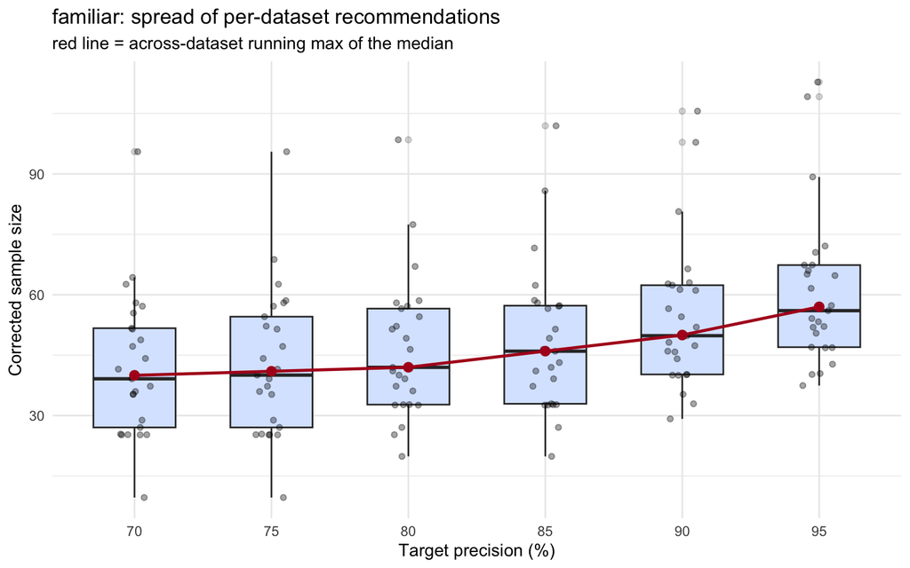

**Sample size needed to reach target split-half reliability:**

| target_reliability | recommended_sample_size | median_reliability |
| --- | --- | --- |
| 0.8 | 20 | 0.959 |
| 0.85 | 20 | 0.959 |
| 0.9 | 20 | 0.959 |
| 0.95 | 20 | 0.959 |

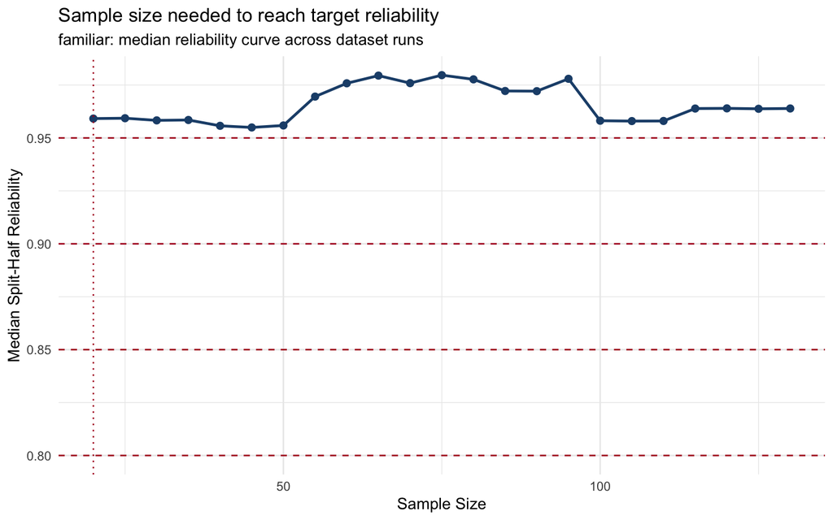

**Recommended n (80% precision + 80% reliability, IQR-trimmed average): 46.0 -> 46 participants/item**

- Precision: 44.5 (mean of 24/25 runs kept after IQR trim)
- Reliability: 47.5 (mean of 24/24 runs kept after IQR trim)

**Per-dataset detail (n at 80% precision, n at 80% reliability, outlier flags):**

| run_id | n_precision | n_reliability | precision_outlier | reliability_outlier |
| --- | --- | --- | --- | --- |
| Gilhooly1980 | 98.5 | 100 | True | False |
| Bogunovic2023 | 77.4 | 60 | False | False |
| DellaRosa2010 | 67 | 60 | False | False |
| Hermans1994 | 58.5 | 80 | False | False |
| Barca2002 | 58 | 70 | False | False |
| Granja2025 | 57.2 |  | False | False |
| Ferre2012 | 56.6 | 60 | False | False |
| Clarke2018 | 54.6 | 70 | False | False |
| Alario1999 | 52.2 | 50 | False | False |
| Gilhooly1977 | 51.5 | 60 | False | False |

[output cut: 15 more lines]

### Concreteness

Based on 18 dataset run(s) for `concrete`.

**Recommended sample size per item, by target precision (% of simulations hitting the AIPE cutoff):**

| target_power | n_runs | mean_recommended_sample_size | median_recommended_sample_size | sd_recommended_sample_size | min_recommended_sample_size | max_recommended_sample_size | recommended_sample_size |
| --- | --- | --- | --- | --- | --- | --- | --- |
| 70 | 18 | 46.43 | 42.29 | 20.23 | 24.99 | 90.93 | 43 |
| 75 | 18 | 47.6 | 42.29 | 20.22 | 24.99 | 91.51 | 43 |
| 80 | 18 | 49.68 | 45.13 | 20.52 | 25.01 | 96.3 | 46 |
| 85 | 18 | 53.5 | 45.13 | 20.04 | 32.27 | 101.49 | 46 |
| 90 | 18 | 57.73 | 51.26 | 20.64 | 32.8 | 106.89 | 52 |
| 95 | 15 | 60.62 | 55.34 | 19.12 | 39.83 | 105.46 | 56 |

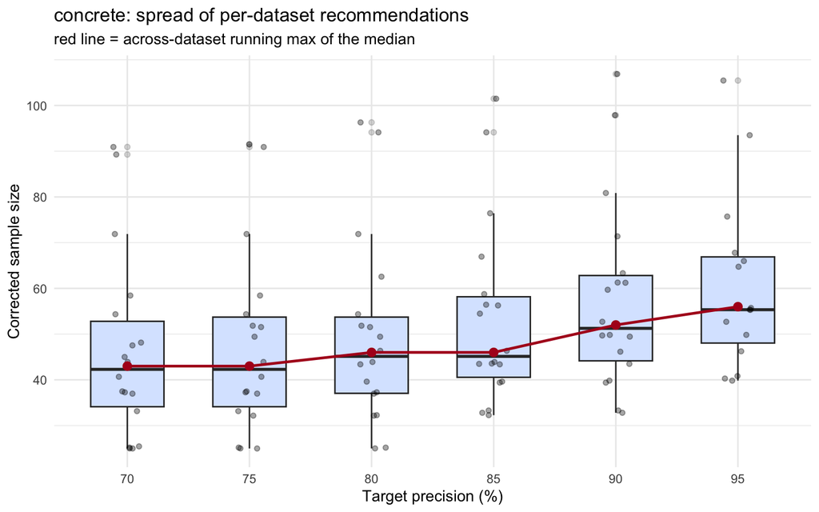

**Sample size needed to reach target split-half reliability:**

| target_reliability | recommended_sample_size | median_reliability |
| --- | --- | --- |
| 0.8 | 30 | 0.966 |
| 0.85 | 30 | 0.966 |
| 0.9 | 30 | 0.966 |
| 0.95 | 30 | 0.966 |

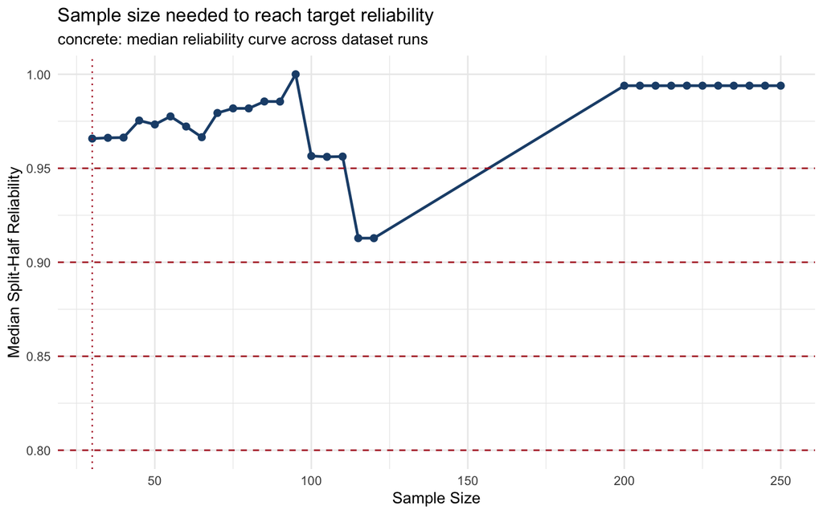

**Recommended n (80% precision + 80% reliability, IQR-trimmed average): 46.4 -> 47 participants/item**

- Precision: 44.0 (mean of 16/18 runs kept after IQR trim)
- Reliability: 48.8 (mean of 17/18 runs kept after IQR trim)

**Per-dataset detail (n at 80% precision, n at 80% reliability, outlier flags):**

| run_id | n_precision | n_reliability | precision_outlier | reliability_outlier |
| --- | --- | --- | --- | --- |
| Jasmin2012 | 96.3 | 200 | True | True |
| Gilhooly1980 | 94.1 | 100 | True | False |
| DellaRosa2010 | 71.9 | 70 | False | False |
| Barca2002 | 62.6 | 70 | False | False |
| Friendly1982 | 54.4 | 70 | False | False |
| Ferre2012 | 51.8 | 60 | False | False |
| Gilhooly1977 | 51.5 | 50 | False | False |
| Gilhooly1980a | 49.4 | 50 | False | False |
| Bogunovic2023 | 46.4 | 40 | False | False |
| Hinojosa2016a | 43.9 | 50 | False | False |

[output cut: 8 more lines]

### Valence

Based on 13 dataset run(s) for `valence`.

**Recommended sample size per item, by target precision (% of simulations hitting the AIPE cutoff):**

| target_power | n_runs | mean_recommended_sample_size | median_recommended_sample_size | sd_recommended_sample_size | min_recommended_sample_size | max_recommended_sample_size | recommended_sample_size |
| --- | --- | --- | --- | --- | --- | --- | --- |
| 70 | 13 | 34.84 | 36.5 | 16.4 | 9.35 | 60.11 | 37 |
| 75 | 13 | 36.71 | 39.41 | 16.3 | 9.35 | 60.11 | 40 |
| 80 | 13 | 38.06 | 40.03 | 16.62 | 9.35 | 61.53 | 41 |
| 85 | 13 | 43.04 | 46.49 | 18.44 | 9.35 | 65.9 | 47 |
| 90 | 13 | 46.87 | 52.65 | 18.53 | 10.07 | 70.29 | 53 |
| 95 | 13 | 54.65 | 58.46 | 18.8 | 20.58 | 78 | 59 |

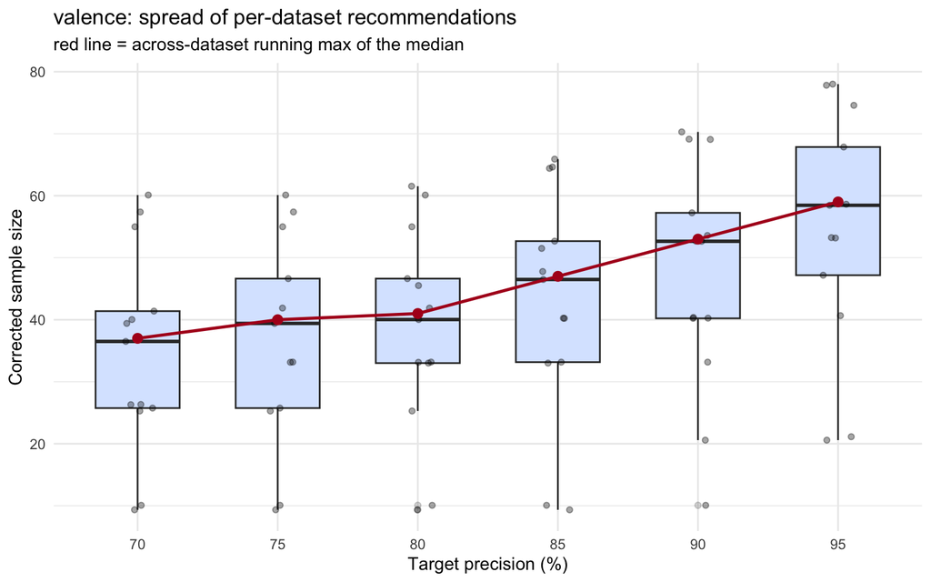

**Sample size needed to reach target split-half reliability:**

| target_reliability | recommended_sample_size | median_reliability |
| --- | --- | --- |
| 0.8 | 20 | 0.942 |
| 0.85 | 20 | 0.942 |
| 0.9 | 20 | 0.942 |
| 0.95 | 30 | 0.963 |

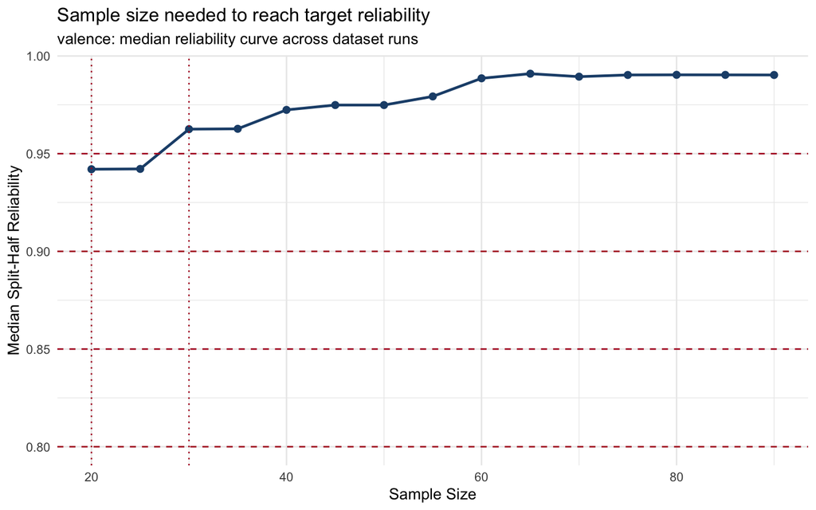

**Recommended n (80% precision + 80% reliability, IQR-trimmed average): 37.6 -> 38 participants/item**

- Precision: 43.2 (mean of 11/13 runs kept after IQR trim)
- Reliability: 32.0 (mean of 10/13 runs kept after IQR trim)

**Per-dataset detail (n at 80% precision, n at 80% reliability, outlier flags):**

| run_id | n_precision | n_reliability | precision_outlier | reliability_outlier |
| --- | --- | --- | --- | --- |
| Ferre2012 | 61.5 | 70 | False | True |
| Imbir2015 | 60.1 | 70 | False | True |
| Hinojosa2016a | 55 | 60 | False | True |
| Bogunovic2023 | 46.6 | 40 | False | False |
| Guasch2016 | 45.5 | 40 | False | False |
| Bonin2018 | 41.9 | 40 | False | False |
| Borsa2025 | 40 | 40 | False | False |
| Chan2024 | 33.2 | 30 | False | False |
| Coso2019 | 33.1 | 30 | False | False |
| Falcinelli2024 | 33 | 30 | False | False |

[output cut: 3 more lines]

### Arousal

Based on 17 dataset run(s) for `arousal`.

**Recommended sample size per item, by target precision (% of simulations hitting the AIPE cutoff):**

| target_power | n_runs | mean_recommended_sample_size | median_recommended_sample_size | sd_recommended_sample_size | min_recommended_sample_size | max_recommended_sample_size | recommended_sample_size |
| --- | --- | --- | --- | --- | --- | --- | --- |
| 70 | 17 | 43.29 | 35.93 | 35.78 | 9.55 | 164.75 | 36 |
| 75 | 17 | 44.24 | 35.93 | 36.98 | 9.55 | 168.8 | 36 |
| 80 | 17 | 46.13 | 40 | 37.63 | 9.55 | 173.2 | 40 |
| 85 | 17 | 47.46 | 40 | 39.11 | 9.55 | 177.9 | 40 |
| 90 | 17 | 52.44 | 46.69 | 39.86 | 9.55 | 185.32 | 47 |
| 95 | 16 | 58.56 | 53.47 | 41.84 | 10.63 | 192.9 | 54 |

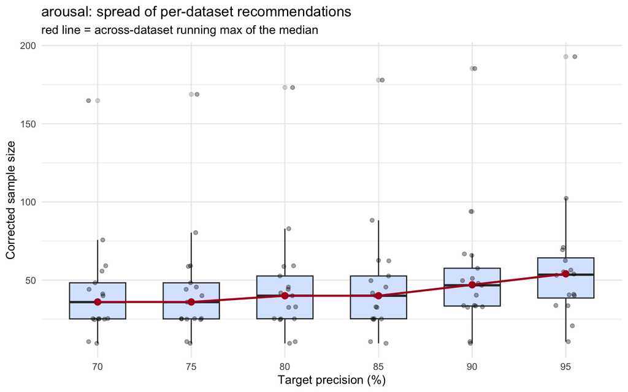

**Sample size needed to reach target split-half reliability:**

| target_reliability | recommended_sample_size | median_reliability |
| --- | --- | --- |
| 0.8 | 20 | 0.881 |
| 0.85 | 20 | 0.881 |
| 0.9 | 25 | 0.923 |
| 0.95 | 80 | 0.95 |

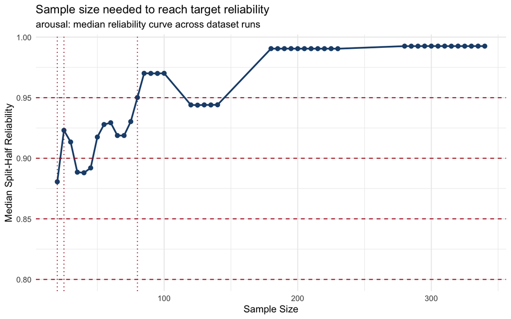

**Recommended n (80% precision + 80% reliability, IQR-trimmed average): 42.2 -> 43 participants/item**

- Precision: 38.2 (mean of 16/17 runs kept after IQR trim)
- Reliability: 46.2 (mean of 13/15 runs kept after IQR trim)

**Per-dataset detail (n at 80% precision, n at 80% reliability, outlier flags):**

| run_id | n_precision | n_reliability | precision_outlier | reliability_outlier |
| --- | --- | --- | --- | --- |
| Janschewitz2008 | 173.2 | 280 | True | True |
| Jasmin2012 | 82.9 | 180 | False | True |
| Kurdi2017 | 59.1 | 120 | False | False |
| Kanske2010 | 58.8 | 80 | False | False |
| Ferre2012 | 52.6 | 60 | False | False |
| Imbir2015 | 45.6 | 50 | False | False |
| Hinojosa2016a | 44.1 | 50 | False | False |
| Bonin2018 | 41.7 | 40 | False | False |
| Bogunovic2023 | 40 | 40 | False | False |
| Borsa2025 | 32.9 | 30 | False | False |

[output cut: 7 more lines]

### Imageability

Based on 12 dataset run(s) for `imagine`.

**Recommended sample size per item, by target precision (% of simulations hitting the AIPE cutoff):**

| target_power | n_runs | mean_recommended_sample_size | median_recommended_sample_size | sd_recommended_sample_size | min_recommended_sample_size | max_recommended_sample_size | recommended_sample_size |
| --- | --- | --- | --- | --- | --- | --- | --- |
| 70 | 12 | 47.97 | 37.34 | 33.06 | 9.11 | 138.5 | 38 |
| 75 | 12 | 50.85 | 41.03 | 37.09 | 9.11 | 156.73 | 42 |
| 80 | 12 | 54.56 | 44.15 | 42.27 | 9.11 | 176.98 | 45 |
| 85 | 12 | 58.16 | 46.81 | 45.31 | 9.11 | 189.35 | 47 |
| 90 | 12 | 63.44 | 50.22 | 46.93 | 20.3 | 201.76 | 51 |
| 95 | 11 | 55.7 | 51.98 | 21.72 | 20.3 | 101.03 | 52 |

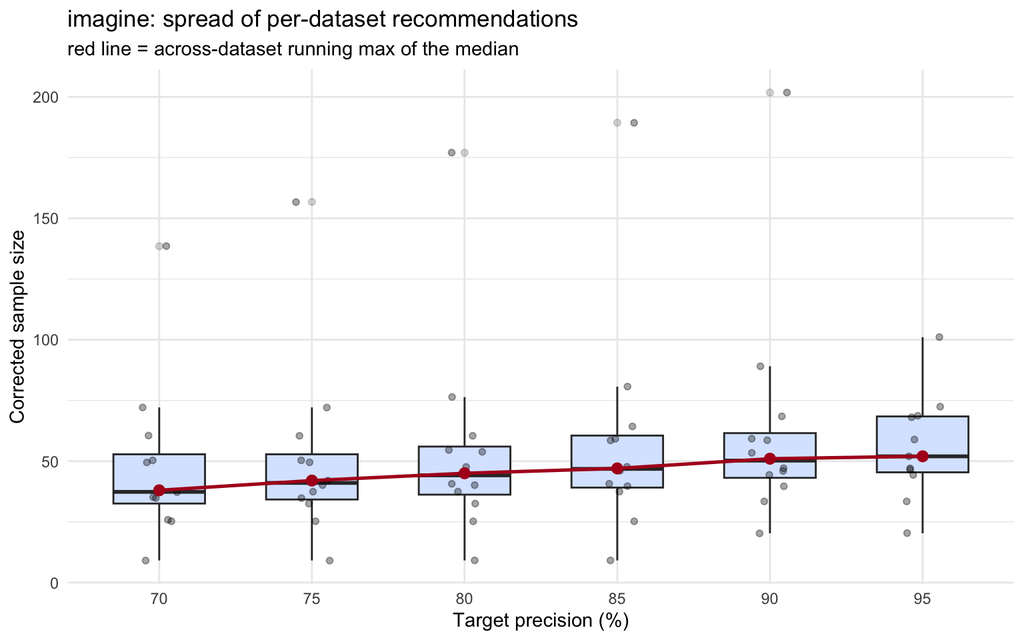

**Sample size needed to reach target split-half reliability:**

| target_reliability | recommended_sample_size | median_reliability |
| --- | --- | --- |
| 0.8 | 20 | 0.955 |
| 0.85 | 20 | 0.955 |
| 0.9 | 20 | 0.955 |
| 0.95 | 20 | 0.955 |

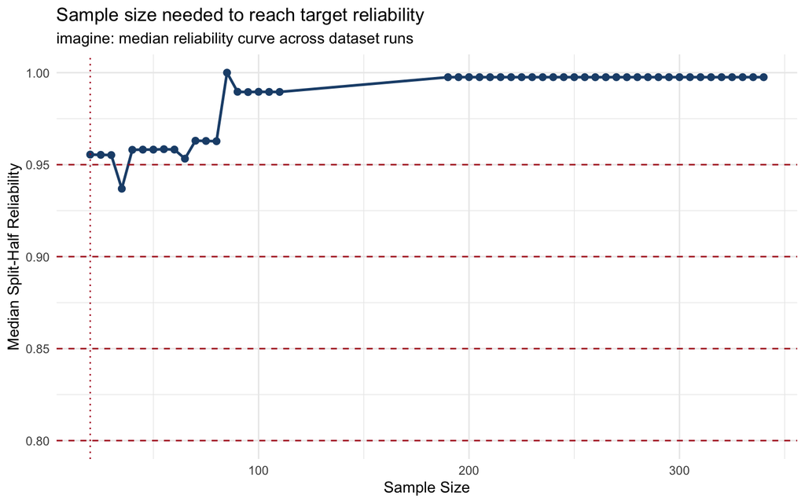

**Recommended n (80% precision + 80% reliability, IQR-trimmed average): 45.4 -> 46 participants/item**

- Precision: 43.4 (mean of 11/12 runs kept after IQR trim)
- Reliability: 47.3 (mean of 11/12 runs kept after IQR trim)

**Per-dataset detail (n at 80% precision, n at 80% reliability, outlier flags):**

| run_id | n_precision | n_reliability | precision_outlier | reliability_outlier |
| --- | --- | --- | --- | --- |
| Clarke2024 | 177 | 190 | True | True |
| DellaRosa2010 | 76.4 | 70 | False | False |
| Berrian1979 | 60.5 | 90 | False | False |
| Bennett2011 | 54.5 | 60 | False | False |
| Barca2002 | 53.8 | 60 | False | False |
| DeDeyne2008 | 47.6 | 40 | False | False |
| Cortese2004 | 40.7 | 40 | False | False |
| Bonin2021 | 40.1 | 40 | False | False |
| Boukadi2016 | 37.4 | 40 | False | False |
| Borsa2025 | 32.5 | 30 | False | False |

[output cut: 2 more lines]

### Age of Acquisition (AoA)

Based on 19 dataset run(s) for `aoa`.

**Recommended sample size per item, by target precision (% of simulations hitting the AIPE cutoff):**

| target_power | n_runs | mean_recommended_sample_size | median_recommended_sample_size | sd_recommended_sample_size | min_recommended_sample_size | max_recommended_sample_size | recommended_sample_size |
| --- | --- | --- | --- | --- | --- | --- | --- |
| 70 | 19 | 39.79 | 39.95 | 16.52 | 8.87 | 65.46 | 40 |
| 75 | 19 | 40.75 | 40.43 | 16.99 | 8.87 | 68.29 | 41 |
| 80 | 19 | 43.8 | 44.7 | 16.66 | 9.6 | 72.74 | 45 |
| 85 | 19 | 48.22 | 50.62 | 17.08 | 18.59 | 77.2 | 51 |
| 90 | 19 | 53.15 | 56.34 | 17.93 | 18.59 | 85.91 | 57 |
| 95 | 16 | 59.57 | 58.39 | 19.04 | 28.21 | 98.17 | 59 |

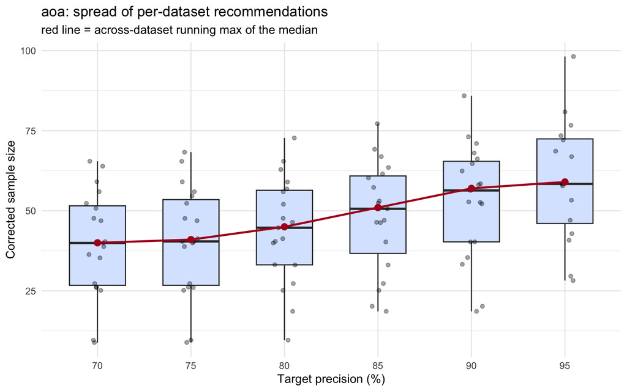

**Sample size needed to reach target split-half reliability:**

| target_reliability | recommended_sample_size | median_reliability |
| --- | --- | --- |
| 0.8 | 20 | 0.916 |
| 0.85 | 20 | 0.916 |
| 0.9 | 20 | 0.916 |
| 0.95 | 30 | 0.97 |

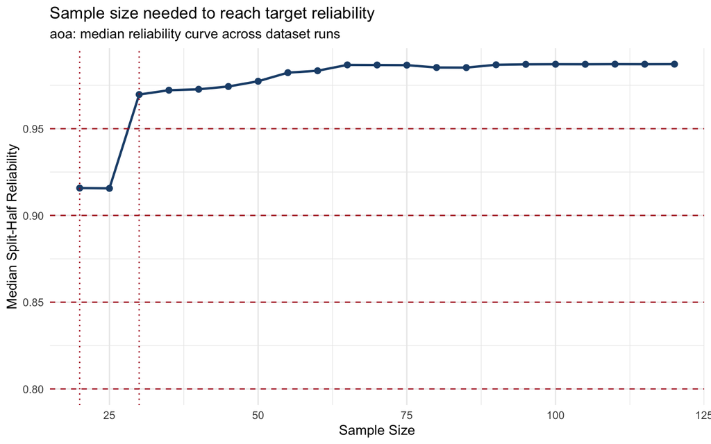

**Recommended n (80% precision + 80% reliability, IQR-trimmed average): 45.1 -> 46 participants/item**

- Precision: 43.8 (mean of 19/19 runs kept after IQR trim)
- Reliability: 46.3 (mean of 19/19 runs kept after IQR trim)

**Per-dataset detail (n at 80% precision, n at 80% reliability, outlier flags):**

| run_id | n_precision | n_reliability | precision_outlier | reliability_outlier |
| --- | --- | --- | --- | --- |
| DellaRosa2010 | 72.7 | 60 | False | False |
| Clarke2024 | 65.5 | 90 | False | False |
| Clarke2018 | 62.9 | 80 | False | False |
| Barca2002 | 59 | 60 | False | False |
| Cameirao2010 | 56.8 | 60 | False | False |
| Alonso2016 | 56 | 70 | False | False |
| Ferrand2008 | 52 | 50 | False | False |
| Carroll1973 | 47.6 | 50 | False | False |
| Birchenough2017 | 46.4 | 40 | False | False |
| Brysbaert2014a | 44.7 | 40 | False | False |

[output cut: 9 more lines]

## Combined recommendation across variables

Our norming study collects all six variables from the same participants per item, so the design has to satisfy every variable’s IQR-trimmed 80/80 recommendation at once - the binding number is the **largest** `recommended_n` across variables below.

```r
combined_recommendation <- purrr::imap_dfr(variable_recommendation, function(rec, v) {
  tibble::tibble(
    variable = v,
    n_precision = rec$precision_mean,
    precision_kept = sprintf("%d/%d", rec$precision_n_kept, rec$precision_n_total),
    n_reliability = rec$reliability_mean,
    reliability_kept = sprintf("%d/%d", rec$reliability_n_kept, rec$reliability_n_total),
    recommended_n = rec$recommended_n
  )
})

combined_recommendation_display <- combined_recommendation %>%
  dplyr::mutate(dplyr::across(c(n_precision, n_reliability, recommended_n), ~ round(.x, 1))) %>%
  dplyr::arrange(dplyr::desc(recommended_n))

DT::datatable(combined_recommendation_display, rownames = FALSE, options = list(dom = "t", pageLength = 10))
```

| variable | n_precision | precision_kept | n_reliability | reliability_kept | recommended_n |
| --- | --- | --- | --- | --- | --- |
| concrete | 44 | 16/18 | 48.8 | 17/18 | 46.4 |
| familiar | 44.5 | 24/25 | 47.5 | 24/24 | 46 |
| imagine | 43.4 | 11/12 | 47.3 | 11/12 | 45.4 |
| aoa | 43.8 | 19/19 | 46.3 | 19/19 | 45.1 |
| arousal | 38.2 | 16/17 | 46.2 | 13/15 | 42.2 |
| valence | 43.2 | 11/13 | 32 | 10/13 | 37.6 |

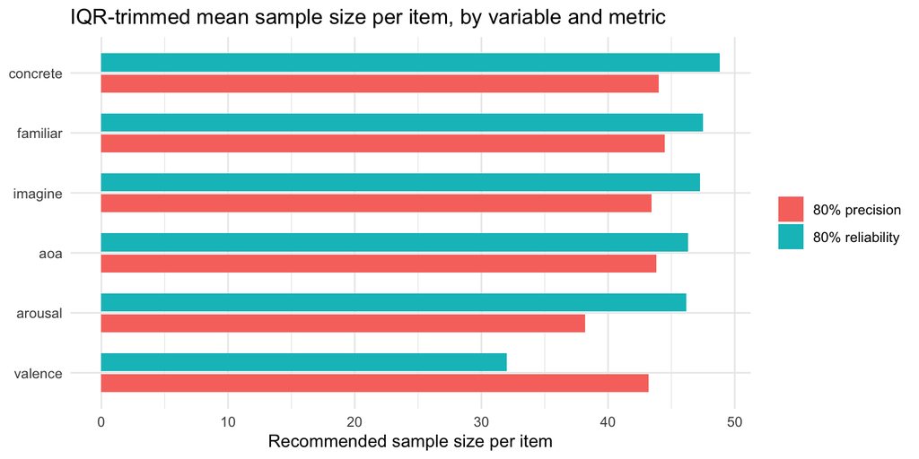

```r
plot_dat <- combined_recommendation %>%
  dplyr::select(variable, n_precision, n_reliability) %>%
  tidyr::pivot_longer(c(n_precision, n_reliability), names_to = "metric", values_to = "n") %>%
  dplyr::mutate(metric = dplyr::recode(metric, n_precision = "80% precision", n_reliability = "80% reliability"))

ggplot2::ggplot(plot_dat, ggplot2::aes(x = reorder(variable, n), y = n, fill = metric)) +
  ggplot2::geom_col(position = ggplot2::position_dodge(width = 0.7), width = 0.6) +
  ggplot2::coord_flip() +
  ggplot2::labs(
    x = NULL, y = "Recommended sample size per item",
    fill = NULL,
    title = "IQR-trimmed mean sample size per item, by variable and metric"
  ) +
  ggplot2::theme_minimal()
```

```r
overall_n_needed <- max(combined_recommendation$recommended_n, na.rm = TRUE)
overall_driver <- combined_recommendation$variable[[which.max(combined_recommendation$recommended_n)]]
overall_n_needed
```

```
## [1] 46.40422
```

**Bottom line:** averaging 80% precision and 80% reliability (after dropping outlier dataset runs via the 1.5 x IQR rule) puts every variable’s recommended sample size at roughly **38-47** participants per item, with concrete needing the most. Our norming study needs at least **47** participants per item to satisfy every variable at once.